# Accessing and plotting FishMIP data

Denisse Fierro Arcos

2022-08-17

# Introduction

This notebook will accessing data from the [Inter-Sectoral Impact Model Intercomparison Project (ISIMIP) Repository](https://data.isimip.org/). There are various datasets available, but as example we will be accessing Output Data > Fisheries & Marine Ecosystems (global) sector > ISIMIP3b simulation.

In this notebook, we will use `Python` to make use of some functions from the `isimip-client` library. We will then move to `R` to manipulate the data and produce maps.

## Setting up the notebook

### Loading R libraries

```r
library(reticulate)
library(tidyverse)
library(metR)
library(lubridate)
library(raster)
```

### Setting up Python for use in an R notebook

Using the `reticulate` package. You have the option to set the path of Python installation using `reticulate::use_python("PATH_TO_PYTHON_INSTALLATION")`, or to point to a specific conda environment using `reticulate::use_condaenv("conda_env")`.

#### Search Python installation path

You can use the `Sys.which()` function in `R` to search the path of the Python installation in your machine using the command below. We will save the path to a variable so we can use it while setting up `Python` access in this notebook.

```r
python_path <- as.character(Sys.which("python"))
```

We can now use the above variable when calling `Python` to this notebook. But as explained above, you can also call a specific environment.

```r
#Point to location of Python installation in your machine
use_python(python_path)

#Alternatively, point to a specific conda environment
#use_condaenv("/opt/conda")
```

## Python-based code

### Loading ISIMIP Client script

The script originally came from the ISIMIP-Client Python package. Their source code is available online in their [repository](https://github.com/ISI-MIP/isimip-client). We will now load the script containing these functions.

Alternatively, you can install the entire library using the following line of code: `!pip install git+https://github.com/ISI-MIP/isimip-client` in a `Python` chunk.

```python
#Calling the script with the ISIMIP-client functions
import client as cl

#Starting a session
client = cl.ISIMIPClient()
```

### Search ISIMIP repository

You can create a query specifying several attributes of the dataset of your interest. In this case, we are interested in Total Catch (`tc` for short), which is a type of Output Data from the ISIMIP3b simulation. For this example, we have also specified an ecological model (`EcoOcean`), the climate forcing used (`GFDL-ESM4` model) and the climate scenario (`historical`).

```python
query = client.datasets(simulation_round = 'ISIMIP3b',\
                           product = 'OutputData',\
                           climate_forcing = 'gfdl-esm4',\
                           climate_scenario = 'historical',\
                           model = 'ecoocean',\
                           variable = 'tc')
```

This query will return a Python dictionary with the results of your search. You can find the name of the keys in the dictionary by typing `query.keys()`. You can inspect the search results by typing `query['name_of_key"]`.

For example, the `query['count']` contains the total number of datasets which met your search requirements. In this case, we found 1 datasets meeting our search requirements.

We can also check the additional metadata associated stored in `query['results']` as shown below.

```python
#We will loop through all search results available
for dataset in query['results']:
  #Print metadata for each entry
  print(dataset['specifiers'])
```

```
## {'model': 'ecoocean', 'period': 'historical', 'region': 'global', 'sector': 'marine-fishery_global', 'product': 'OutputData', 'variable': 'tc', 'time_step': 'monthly', 'soc_scenario': 'histsoc', 'sens_scenario': 'default', 'bias_adjustment': 'nobasd', 'climate_forcing': 'gfdl-esm4', 'climate_scen…
```

```python
#Empty lists to save URLs linking to files
urls = []
urls_sub = []

#Looping through each entry available in search results
for datasets in query['results']:
  for paths in dataset['files']:
    urls.append(paths['file_url'])
    urls_sub.append(paths['path'])
```

#### Optional step

If you are looking for a subset of the global dataset, you can set a bounding box and only extract data for your area of interest. In this case, we will extract information for the Southern Ocean only.

```python
#We use the cutout function to create a bounding box for our dataset
SO_data_URL = client.cutout(urls_sub, bbox=[-90, -40, -180, 180])
```

#Downloading data to disk We will download the data into the `data` folder.

```python
client.download(SO_data_URL['file_url'], path = 'data/', validate = False, extract = True)
```

```python
urls
```

```
## ['https://files.isimip.org/ISIMIP3b/OutputData/marine-fishery_global/EcoOcean/gfdl-esm4/historical/ecoocean_gfdl-esm4_nobasd_historical_histsoc_default_tc_global_monthly_1950_2014.nc']
```

## Checking contents of netcdfile

From now on we will switch to `R` again.

```r
#Provide file path to netcdf that was recently downloaded.
data_file <- "data/ecoocean_gfdl-esm4_nobasd_historical_histsoc_default_tc_lat-90.0to-40.0lon-180.0to180.0_monthly_1950_2014.nc"

#Check contents of netcdf
GlanceNetCDF(data_file)
```

[output not shown]

```r
#Get missing values from netcdf attributes
# miss_val <- nc_open(data_file)
# NA_fill <- ncatt_get(miss_val, "tc")$missing_value
# tc_ar <- ncvar_get(miss_val, "tc")

#Loading as raster to obtain missing values
tc_raster <- raster(data_file)
NA_val <- tc_raster@file@nodatavalue
```

## Loading data

```r
tc_SO <- ReadNetCDF(data_file, vars = "tc") %>%
  mutate(tc = case_when(tc >= NA_val ~ NA_real_,
         T ~ tc))
## Manipulating data
# Calculating climatological mean for all values available between 1960 and 2020.

clim_tc <- tc_SO %>%
  #Add a column with years
  mutate(year = lubridate::year(time)) %>%
  #Extracting data between 1960 and 2020
  filter(year >= 1960 & year <= 2020) %>%
  #Calculating climatological mean for total catch per pixel
  group_by(lat, lon) %>%
  summarise(mean_tc = mean(tc, na.rm = F))
```

## Plotting climatology

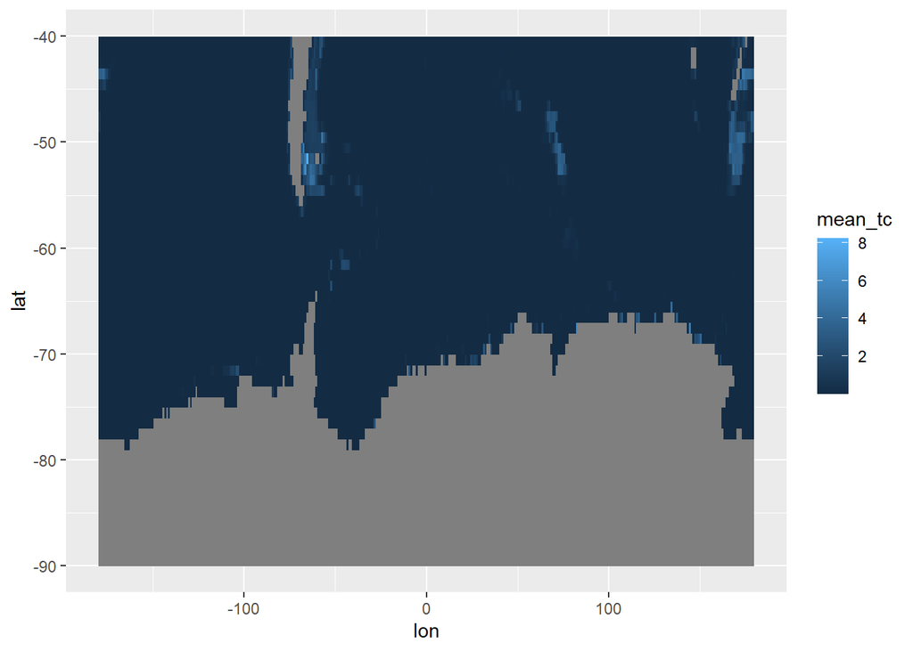

```r
clim_tc %>%
  ggplot(aes(y = lat, x = lon))+
  geom_raster(aes(fill = mean_tc))
```